# Lab02: Multiple Regression Analysis, Factors and Interaction Effects

Author

Shiu-Ting Ling

**Handout date:** Monday, February 16, 2026

**FIRM DUE DATA:** Monday, March 02, 2026, by midnight

**Submission Format:** Submit your lab as R Markdown document `Lab02YourName.rmd` to eLearning’s *SumitLab02* link in the **Labs** folder. Put your name behind the author’s keyword into the header of the YAML header of the Markdown file. Make sure that your R Markdown document renders properly into an `html` document. Otherwise, we will *not* be able to grade your lab!

*This lab counts 8 points towards your final grade.*

Your lab answer has obtained *xx* out of 8 points?

# Task 1: Partial Regression Coefficient [2 points]

Use the `CONCORD1.SAV` file for this task. You will demonstrate that in multiple regression the partial effect of an independent variable is free from any linear effects of the remaining independent variables in a regression model.

**1.1** Run the multiple model `water81~income+water80+educat` and *interpret* its regression coefficients. [0.5 points]

*Your answer goes here*

### answer 1-1

```r
rm(list=ls())                          # Clear environment
oldpar <- par()                        # save default graphical parameters
cat("\014")                            # Clear the Console
```

```r
library(car)
concord <- foreign::read.spss("Concord1.sav", to.data.frame=TRUE)

## Multiple Regression Model
mod1.lm <- lm(water81 ~ income + water80 + educat, data=concord)
summary(mod1.lm)
```

```
Call:
lm(formula = water81 ~ income + water80 + educat, data = concord)

Residuals:
    Min      1Q  Median      3Q     Max
-4635.2  -473.4   -65.0   405.6  4831.1

Coefficients:
             Estimate Std. Error t value Pr(>|t|)
(Intercept) 811.18243  196.29879   4.132 4.22e-05 ***
income       24.71652    3.54917   6.964 1.06e-11 ***
water80       0.59130    0.02477  23.872  < 2e-16 ***
educat      -49.88881   14.18671  -3.517 0.000478 ***
---
Signif. codes:  0 '***' 0.001 '**' 0.01 '*' 0.05 '.' 0.1 ' ' 1

Residual standard error: 914.9 on 492 degrees of freedom
Multiple R-squared:  0.6233,    Adjusted R-squared:  0.621
F-statistic: 271.3 on 3 and 492 DF,  p-value: < 2.2e-16
```

The multiple regression model `water81 ~ income + water80 + educat` produces the following results:

The model fits the data reasonably well, with an adjusted R² of 0.621, meaning that income, prior water use, and education together explain about 62% of the variation in 1981 household water consumption. The overall F-test is highly significant (F = 271.3, p < 0.001), so the model as a whole is statistically meaningful.

**Intercept (811.18, p < 0.001):** When income, water80, and educat are all zero, the predicted 1981 water use would be about 811 gallons. This value doesn’t have much practical meaning since a household with zero income and zero prior water use is unrealistic.

**income (24.72, p < 0.001):** Holding water80 and educat constant, each additional $1,000 of household income is associated with an increase of about **24.72 gallons** in 1981 water consumption. This suggests that wealthier households tend to use more water even after controlling for past usage habits and education level.

**water80 (0.591, p < 0.001):** Holding income and educat constant, each additional gallon used in 1980 predicts an increase of about **0.59 gallons** in 1981 water use. This makes intuitive sense — households tend to maintain their water consumption habits over time, so past usage is a strong baseline predictor of current usage.

**educat (−49.89, p < 0.001):** Holding income and water80 constant, each additional year of education is associated with a decrease of about **49.89 gallons** in 1981 water consumption. This negative relationship might reflect that more educated households are more aware of conservation efforts.

**1.2** Calculate the residuals of the two models [a] `water81~educat+water80` and [b] `income~educat+water80`. *What are these residuals* specifically measuring? [0.5 points]

*Your answer goes here*

### answer 1-2

```r
## Model [a] water81~educat+water80
mod1a.lm <- lm(water81 ~ educat + water80, data=concord)
summary(mod1a.lm)
```

```
Call:
lm(formula = water81 ~ educat + water80, data = concord)

Residuals:
    Min      1Q  Median      3Q     Max
-4849.4  -424.4   -95.3   359.4  5289.0

Coefficients:
             Estimate Std. Error t value Pr(>|t|)
(Intercept) 766.16393  205.42601   3.730 0.000214 ***
educat      -16.86832   14.00016  -1.205 0.228833
water80       0.64730    0.02453  26.387  < 2e-16 ***
---
Signif. codes:  0 '***' 0.001 '**' 0.01 '*' 0.05 '.' 0.1 ' ' 1

Residual standard error: 958 on 493 degrees of freedom
Multiple R-squared:  0.5861,    Adjusted R-squared:  0.5845
F-statistic: 349.1 on 2 and 493 DF,  p-value: < 2.2e-16
```

```r
## Model [b] income~educat+water80
mod1b.lm <- lm(income ~ educat + water80, data=concord)
summary(mod1b.lm)
```

```
Call:
lm(formula = income ~ educat + water80, data = concord)

Residuals:
    Min      1Q  Median      3Q     Max
-27.224  -8.241  -1.459   5.839  66.174

Coefficients:
              Estimate Std. Error t value Pr(>|t|)
(Intercept) -1.8213936  2.4896108  -0.732    0.465
educat       1.3359684  0.1696716   7.874 2.21e-14 ***
water80      0.0022653  0.0002973   7.620 1.31e-13 ***
---
Signif. codes:  0 '***' 0.001 '**' 0.01 '*' 0.05 '.' 0.1 ' ' 1

Residual standard error: 11.61 on 493 degrees of freedom
Multiple R-squared:  0.2126,    Adjusted R-squared:  0.2094
F-statistic: 66.56 on 2 and 493 DF,  p-value: < 2.2e-16
```

```r
## Calculate Residuals
e.water81 <- residuals(mod1a.lm)   # Residuals from model [a]: water81|educat+water80
e.income  <- residuals(mod1b.lm)   # Residuals from model [b]: income|educat+water80
```

**Model [a]:** `water81 ~ educat + water80`

The residuals from this model represent the variation in 1981 water consumption that **cannot be explained by education level or prior water use (water80)**. In other words, after statistically removing the linear effects of `educat` and `water80` from `water81`, what remains is the “pure” variation in 1981 water use that is free from any linear influence of those two variables. This leftover variation is what `income` will later try to explain.

**Model [b]:** `income ~ educat + water80`

Similarly, the residuals from this model represent the variation in household income that **cannot be explained by education level or prior water use**. After removing the linear effects of `educat` and `water80` from `income`, what remains is the “pure” variation in income that is independent of those two control variables.

**The reason we need both sets of residuals:**

The key idea here is that in multiple regression, the partial coefficient of `income` reflects its relationship with `water81` *after* the shared linear effects of `educat` and `water80` have already been accounted for. By extracting the residuals from both models, we are essentially “cleaning” both variables — we are left with the part of `water81` and the part of `income` that have nothing to do with `educat` or `water80`. The relationship between these two cleaned-up residuals is precisely what the partial regression coefficient of `income` captures in the full multiple regression model.

**1.3** Generate the partial regression leverage scatterplot of the water residuals against the income residuals. Make sure to use properly labeled axes. *Briefly interpret the scatterplot.* [0.5 points]

*Your answer goes here*

### answer 1-3

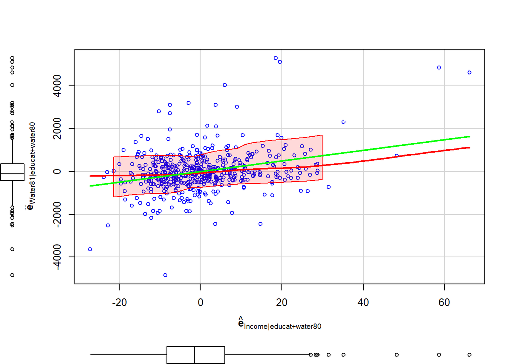

```r
## Partial Regression Leverage Plot
## water81 residuals ~ income residuals
## (after removing linear effects of educat+water80)
car::scatterplot(e.water81 ~ e.income,
            xlab=bquote(hat(bold(e))["Income|educat+water80"]),
            ylab=bquote(hat(bold(e))["Water81|educat+water80"]),
            smooth=list(span=0.5, lty.smooth=1, col.smooth="red", col.var="red"),
            regLine=list(col="green"))
```

The partial regression leverage scatterplot shows the relationship between the residuals of `water81` (after removing the linear effects of `educat` and `water80`) plotted against the residuals of `income` (after removing the same linear effects of `educat` and `water80`). In other words, both axes represent the “leftover” variation in each variable that cannot be explained by education level or prior water use.

The green regression line shows a clear **positive slope**, indicating that households with higher-than-expected income (given their education and prior water use) also tend to have higher-than-expected 1981 water consumption. This positive relationship reflects the **pure partial effect of income on water81**, completely free from any linear influence of `educat` and `water80`.

However, there are a number of **outliers** visible in the plot, particularly some observations with very high water residuals and a few extreme income residuals on the right side of the plot. These points may have noticeable influence on the slope estimate. The loess smoother (red curve) follows a similar upward trend to the regression line in the central region but diverges slightly at the extremes, suggesting the relationship is roughly linear but may be pulled by those outlying observations.

Overall, the scatterplot confirms that income has a **positive partial association** with 1981 water consumption even after controlling for education and prior water use habits.

**1.4** Estimate a bivariate regression model of the water residuals on the income residuals and compare its estimate slope coefficient against the slope coefficient for `income` of the multiple model from task 1.1. *Why are you allowed to* suppress the intercept in this model? [0.5 point]

*Your answer goes here*

### answer 1-4

```r
## Bivariate Regression of Residuals
## Suppress intercept (-1) because residual means are zero
## Compare slope with income coefficient from mod1.lm (Task 1.1)
summary(lm(e.water81 ~ e.income - 1))                  # suppress intercept: residual means = 0
```

```
Call:
lm(formula = e.water81 ~ e.income - 1)

Residuals:
    Min      1Q  Median      3Q     Max
-4635.2  -473.4   -65.0   405.6  4831.1

Coefficients:
         Estimate Std. Error t value Pr(>|t|)
e.income   24.717      3.538   6.985 9.21e-12 ***
---
Signif. codes:  0 '***' 0.001 '**' 0.01 '*' 0.05 '.' 0.1 ' ' 1

Residual standard error: 912.2 on 495 degrees of freedom
Multiple R-squared:  0.08973,   Adjusted R-squared:  0.08789
F-statistic: 48.79 on 1 and 495 DF,  p-value: 9.213e-12
```

```r
## Compare coefficients
cat("Slope from residual regression:        ",
    coef(lm(e.water81 ~ e.income - 1))["e.income"], "\n")
```

```
Slope from residual regression:         24.71652
```

```r
cat("income coefficient from full model:    ",
    coef(mod1.lm)["income"], "\n")
```

```
income coefficient from full model:     24.71652
```

The bivariate regression of the water residuals on the income residuals (with the intercept suppressed) produces a slope coefficient of **24.717**, which is virtually identical to the `income` coefficient of **24.717** from the full multiple regression model in Task 1.1. The two values match exactly up to rounding, which confirms the key theoretical point of this exercise.

This result demonstrates that **the partial regression coefficient of `income` in the multiple model is mathematically equivalent to the slope obtained by regressing the residuals of `water81` on the residuals of `income`**, after both variables have had the linear effects of `educat` and `water80` removed. In other words, OLS automatically “cleans out” the influence of the other independent variables when estimating each partial coefficient.

**Note: the reasons we were allowed to suppress the intercept:**

We are allowed to suppress the intercept because the residuals from any OLS regression always have a mean of exactly zero by construction. Since both `e.water81` and `e.income` have means of zero, the regression line must pass through the origin (0, 0). Including an intercept would be redundant — it would simply estimate to approximately zero anyway. Therefore, forcing the intercept to zero with `- 1` is not only justified but actually the more correct specification for this particular model.

# Task 2: A Multiple Regression Model with Factors and Partial F-test [5 points]

Use the dBase data file `PROVINCES.DBF` (read it into R with the function `foreign::read.dbf`)

You will experiment with regression models that aim at explaining the 1994 total fertility rate `TOTFERTRAT` (number of children born by a woman during her lifetime) within the 95 Italian provinces. The following independent variables are: [a] the metric illiteracy rate `ILLITERRAT`, [b] the metric average woman’s age at first marriage `FEMMARAGE`, [c] the metric divorce rate `DIVORCERAT`, [d] the metric televisions per household `TELEPERFAM` and [e] a regional factor `REGION` denoting whether a province is located on the islands of Sicily or Sardinia, or in the southern, central or northern parts of Italy’s mainland.

Note: please do *not* perform variable transformations in the task.

**2.1** Use common sense arguments *how* these four metric variables will influence the provincial fertility rates. Use one or two sentences per explanation and formulate preferably one sided null and alternative hypotheses based on your explanation. The statistical hypotheses should be *type-set* properly, for instance, as $H_0:\beta_{VarXYZ}\leq0$ against $H_1:\beta_{VarXYZ}>0$. Format everything in the table shown below. [0.5 points]

### answer 2-1

[output not shown]

**2.2** Generate a scatterplot matrix showing the dependent variable and the four *metric* independent variables. Also generate a boxplot of the fertility rate against the factor variable `REGION`. Briefly interpret both plots. [0.75 points]

*Your answer goes here*

### answer 2-2

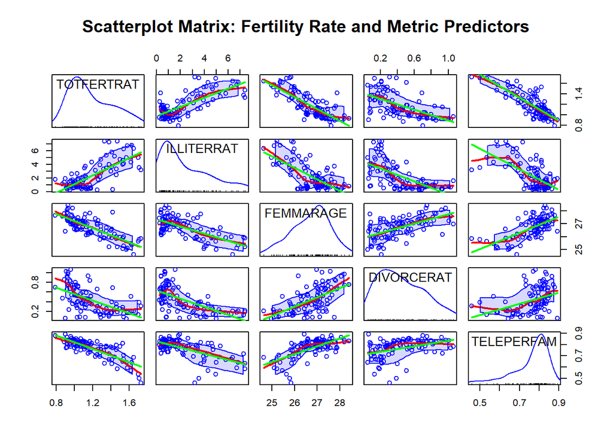

```r
## Read in the PROVINCES.DBF data file
provinces <- foreign::read.dbf("PROVINCES.DBF")

## Scatterplot matrix: dependent variable + four metric independent variables
##  Exclude factor variable from scatterplotMatrix
car::scatterplotMatrix(
  ~TOTFERTRAT+ILLITERRAT+FEMMARAGE+DIVORCERAT+TELEPERFAM,
  data=provinces,
  diagonal=list(method="density"),
  smooth=list(span=0.5,
              lty.smooth=1,
              col.smooth="red"),
  regLine=list(col="green"),
  main="Scatterplot Matrix: Fertility Rate and Metric Predictors"
)
```

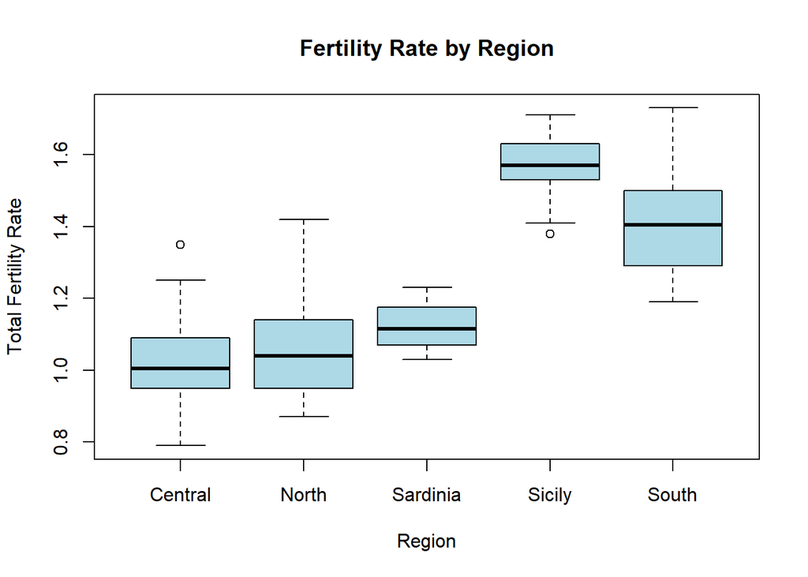

```r
## Boxplot of fertility rate against the factor variable REGION
## Ref: Chapt03a.r line 66 -- evaluate factor variable in boxplot
boxplot(TOTFERTRAT~REGION, data=provinces,
        xlab="Region", ylab="Total Fertility Rate",
        main="Fertility Rate by Region",
        col="lightblue")
```

**Scatterplot Matrix Interpretation:**

From the scatterplot matrix, we can see that `TOTFERTRAT` has a fairly clear positive relationship with `ILLITERRAT` — provinces with higher illiteracy rates tend to have higher fertility rates. On the other hand, `FEMMARAGE`, `DIVORCERAT`, and `TELEPERFAM` all show negative relationships with `TOTFERTRAT`, meaning that as these variables increase, the fertility rate tends to go down. These patterns are generally consistent with what we expected from our common sense arguments in task 2.1. It is also worth noting that several predictors are correlated with each other — for example, `ILLITERRAT` seems negatively related to both `FEMMARAGE` and `TELEPERFAM`, which suggests that multicollinearity could become an issue in the regression model.

**Boxplot Interpretation:**

The boxplot shows quite noticeable differences in fertility rates across the five Italian regions. Sicily and the South have clearly higher median fertility rates (around 1.55 and 1.40 respectively) compared to Central Italy, the North, and Sardinia, which all cluster around 1.0 to 1.1. This suggests that geographic location plays an important role in explaining fertility rate variation, and that the `REGION` factor is likely to be a meaningful predictor in our regression model.

**2.3** Run a base model multiple regression with the four *metric* variables to explain the variation of the fertility rates. Interpret this model [a] in the light of your earlier stated hypotheses in task 2.1, [b] the significances of the estimate regression coefficients and [c] the goodness of fit. [0.75 points]

*Your answer goes here*

### answer 2-3

```r
## Base model: multiple regression with four metric variables only
mod2.lm <- lm(TOTFERTRAT ~ ILLITERRAT+FEMMARAGE+DIVORCERAT+TELEPERFAM, data=provinces)
summary(mod2.lm)
```

```
Call:
lm(formula = TOTFERTRAT ~ ILLITERRAT + FEMMARAGE + DIVORCERAT +
    TELEPERFAM, data = provinces)

Residuals:
     Min       1Q   Median       3Q      Max
-0.21906 -0.06267 -0.00966  0.05425  0.41272

Coefficients:
             Estimate Std. Error t value Pr(>|t|)
(Intercept)  4.496337   0.513726   8.752 1.13e-13 ***
ILLITERRAT   0.020377   0.008735   2.333   0.0219 *
FEMMARAGE   -0.088837   0.020771  -4.277 4.71e-05 ***
DIVORCERAT  -0.112265   0.055648  -2.017   0.0466 *
TELEPERFAM  -1.226364   0.183037  -6.700 1.76e-09 ***
---
Signif. codes:  0 '***' 0.001 '**' 0.01 '*' 0.05 '.' 0.1 ' ' 1

Residual standard error: 0.1035 on 90 degrees of freedom
Multiple R-squared:  0.8096,    Adjusted R-squared:  0.8012
F-statistic: 95.69 on 4 and 90 DF,  p-value: < 2.2e-16
```

```r
cbind(Estimate=coef(mod2.lm), confint(mod2.lm))     # print confidence intervals for parameter estimates
```

```
               Estimate       2.5 %       97.5 %
(Intercept)  4.49633724  3.47573155  5.516942917
ILLITERRAT   0.02037729  0.00302309  0.037731490
FEMMARAGE   -0.08883705 -0.13010151 -0.047572580
DIVORCERAT  -0.11226497 -0.22282020 -0.001709743
TELEPERFAM  -1.22636404 -1.58999801 -0.862730064
```

**[a] Hypotheses from Task 2.1:**

All four variables show coefficient signs that match our expectations from task 2.1. `ILLITERRAT` has a positive coefficient (0.0204), consistent with our hypothesis $H_1: \beta_{ILLITERRAT} > 0$. The remaining three variables — `FEMMARAGE` (−0.0888), `DIVORCERAT` (−0.1123), and `TELEPERFAM` (−1.2264) — all have negative coefficients, which is exactly what we predicted. So overall, the direction of all four effects agrees with our common sense arguments.

**[b] Significance of the Regression Coefficients:**

All four predictors are statistically significant at the 5% level. `TELEPERFAM` is by far the most significant variable ($t = -6.70$, $p < 0.001$), followed by `FEMMARAGE` ($t = -4.28$, $p < 0.001$). Both `ILLITERRAT` ($t = 2.33$, $p = 0.022$) and `DIVORCERAT` ($t = -2.02$, $p = 0.047$) are significant at the 5% level but are relatively weaker. The confidence intervals for all four coefficients also do not include zero, which further confirms their significance.

**[c] Goodness of Fit:**

The model fits the data quite well. The adjusted $R^2 = 0.801$ tells us that about **80% of the variation** in provincial fertility rates is explained by these four metric variables alone, which is quite impressive for a social science dataset. The overall F-statistic is $F(4, 90) = 95.69$ with $p < 0.001$, strongly rejecting the null hypothesis that all slope coefficients are simultaneously zero. The residual standard error is 0.1035, meaning our predictions are typically off by about 0.10 children per woman.

**2.4** Calculate the standardized *beta-coefficients* for the multiple model form task 2.3. Rank the independent variables according to the absolute strength of their effects on the fertility rates and plot the beta coefficients with the `coefplot( )` function. Use proper options for the `coefplot( )` function. [0.75 points]

*Your answer goes here*

### answer 2-4

```r
## Beta weights (standardized coefficients) for mod2.lm

provincesNew   <- provinces[ ,sapply(provinces,is.numeric)]       # Remove non-numeric variables
provincesScale <- as.data.frame(scale(provincesNew))              # apply z-transformation with scale function
                                                                   # dataframe provincesScale holds the transformed values
mod3.lm <- lm(TOTFERTRAT ~ -1+ILLITERRAT+FEMMARAGE+DIVORCERAT+TELEPERFAM,
              data=provincesScale)
summary(mod3.lm)                                                   # display beta-values.
```

```
Call:
lm(formula = TOTFERTRAT ~ -1 + ILLITERRAT + FEMMARAGE + DIVORCERAT +
    TELEPERFAM, data = provincesScale)

Residuals:
     Min       1Q   Median       3Q      Max
-0.94379 -0.27001 -0.04162  0.23371  1.77813

Coefficients:
           Estimate Std. Error t value Pr(>|t|)
ILLITERRAT  0.17303    0.07377   2.346   0.0212 *
FEMMARAGE  -0.30905    0.07186  -4.301 4.27e-05 ***
DIVORCERAT -0.12638    0.06230  -2.029   0.0454 *
TELEPERFAM -0.44537    0.06611  -6.737 1.43e-09 ***
---
Signif. codes:  0 '***' 0.001 '**' 0.01 '*' 0.05 '.' 0.1 ' ' 1

Residual standard error: 0.4434 on 91 degrees of freedom
Multiple R-squared:  0.8096,    Adjusted R-squared:  0.8013
F-statistic: 96.75 on 4 and 91 DF,  p-value: < 2.2e-16
```

```
`height` was translated to `width`.
```

```
`height` was translated to `width`.
```

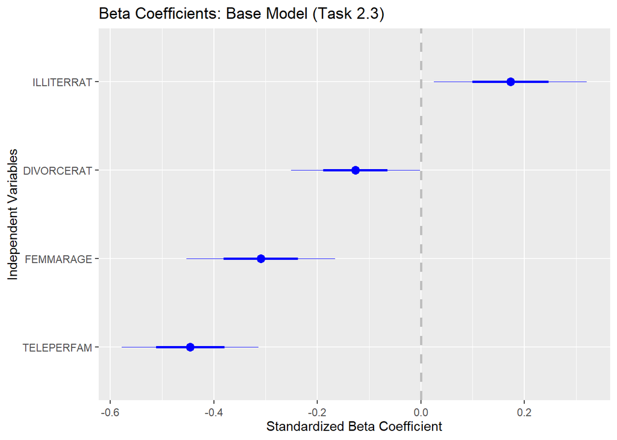

```r
## Coefficient plot useful for beta weights because the parameters are on the same scale
library(coefplot)
coefplot(mod3.lm, sort="magnitude",
         xlab="Standardized Beta Coefficient",
         ylab="Independent Variables",
         title="Beta Coefficients: Base Model (Task 2.3)")
```

Based on the standardized beta coefficients, the ranking of the independent variables by **absolute strength of effect** on fertility rates is:

| Rank | Variable | Beta Coefficient | Direction |
| --- | --- | --- | --- |
| 1st | `TELEPERFAM` | −0.445 | negative |
| 2nd | `FEMMARAGE` | −0.309 | negative |
| 3rd | `ILLITERRAT` | +0.173 | positive |
| 4th | `DIVORCERAT` | −0.126 | negative |

`TELEPERFAM` has the strongest effect on fertility rates with a beta coefficient of −0.445, meaning that a one standard deviation increase in televisions per household is associated with a 0.445 standard deviation **decrease** in fertility rate — making it by far the most influential predictor in this model. `FEMMARAGE` comes in second (−0.309), suggesting that women marrying later also has a fairly strong suppressing effect on fertility. `ILLITERRAT` ranks third (0.173) with a positive effect, while `DIVORCERAT` has the weakest influence (−0.126) among the four variables.

The `coefplot` confirms this ranking visually — `TELEPERFAM` sits furthest to the left of the zero line, while `DIVORCERAT` has a confidence interval that barely stays on the negative side, reflecting its borderline significance we already saw in task 2.3.

**2.5** Run five separate regressions on the [a] independent metric variables as well as [b] the dependent fertility rate using the factor `REGION` as independent variable.

Does the `REGION` factor explain variation of the four independent variables as well as the fertility rate, i.e., what are the $R^2$’s? [0.75 points]

Hint: To calibrate all five models with one function call you can use the regression formula syntax `cbind(TOTFERTRAT,ILLITERRAT,FEMMARAGE,DIVORCERAT,TELEPERFAM)~REGION`. The `summary` function gives you the results for all five models.

*Your answer goes here*

### answer 2-5

```r
## Run five separate regressions using REGION factor as independent variable
region.lm <- lm(cbind(TOTFERTRAT,ILLITERRAT,FEMMARAGE,DIVORCERAT,TELEPERFAM)~REGION,
                data=provinces)
summary(region.lm)   # summary gives results for all five models
```

```
Response TOTFERTRAT :

Call:
lm(formula = TOTFERTRAT ~ REGION, data = provinces)

Residuals:
     Min       1Q   Median       3Q      Max
-0.23300 -0.09275 -0.01300  0.07167  0.36333

Coefficients:
               Estimate Std. Error t value Pr(>|t|)
(Intercept)     1.02300    0.02205  46.405   <2e-16 ***
REGIONNorth     0.03367    0.03118   1.080    0.283
REGIONSardinia  0.09950    0.06427   1.548    0.125
REGIONSicily    0.53700    0.04589  11.702   <2e-16 ***
REGIONSouth     0.39473    0.03389  11.647   <2e-16 ***
---
Signif. codes:  0 '***' 0.001 '**' 0.01 '*' 0.05 '.' 0.1 ' ' 1

Residual standard error: 0.1207 on 90 degrees of freedom
Multiple R-squared:  0.7409,    Adjusted R-squared:  0.7294
F-statistic: 64.34 on 4 and 90 DF,  p-value: < 2.2e-16


Response ILLITERRAT :

Call:
lm(formula = ILLITERRAT ~ REGION, data = provinces)

Residuals:
     Min       1Q   Median       3Q      Max
-2.82455 -0.50394 -0.07267  0.34756  2.83545

Coefficients:
               Estimate Std. Error t value Pr(>|t|)
(Intercept)      1.4157     0.1844   7.676 1.89e-11 ***
REGIONNorth     -0.7630     0.2608  -2.925  0.00435 **
REGIONSardinia   1.8068     0.5377   3.360  0.00114 **
REGIONSicily     3.2466     0.3839   8.457 4.64e-13 ***
REGIONSouth      3.1689     0.2835  11.176  < 2e-16 ***
```

[output cut: 63 more lines]

```
-0.247360 -0.025351  0.008611  0.033786  0.106420

Coefficients:
                Estimate Std. Error t value Pr(>|t|)
(Intercept)     0.812704   0.010775  75.422  < 2e-16 ***
REGIONNorth    -0.006805   0.015239  -0.447    0.656
REGIONSardinia -0.049512   0.031416  -1.576    0.119
REGIONSicily   -0.180715   0.022431  -8.057 3.12e-12 ***
REGIONSouth    -0.106844   0.016566  -6.449 5.48e-09 ***
---
Signif. codes:  0 '***' 0.001 '**' 0.01 '*' 0.05 '.' 0.1 ' ' 1

Residual standard error: 0.05902 on 90 degrees of freedom
Multiple R-squared:  0.5306,    Adjusted R-squared:  0.5098
F-statistic: 25.43 on 4 and 90 DF,  p-value: 4.118e-14
```

The results show that `REGION` does a fairly good job of explaining the variation in all five variables. All five models have statistically significant overall F-tests ($p < 0.001$), indicating that the `REGION` factor as a whole explains a nontrivial share of variation in each response variable.

The $R^2$ values are summarized below:

| Response Variable | $R^2$ | Interpretation |
| --- | --- | --- |
| `TOTFERTRAT` | 0.741 | REGION explains 74.1% of fertility rate variation |
| `ILLITERRAT` | 0.749 | REGION explains 74.9% of illiteracy rate variation |
| `FEMMARAGE` | 0.629 | REGION explains 62.9% of female marriage age variation |
| `DIVORCERAT` | 0.423 | REGION explains 42.3% of divorce rate variation |
| `TELEPERFAM` | 0.531 | REGION explains 53.1% of televisions per household variation |

These results are quite revealing. `REGION` explains a large share of the variation not only in the dependent variable `TOTFERTRAT` ($R^2 = 0.741$), but also in the metric predictors themselves — especially `ILLITERRAT` ($R^2 = 0.749$) and `FEMMARAGE` ($R^2 = 0.629$). This tells us that where a province is located geographically is strongly associated with its socioeconomic characteristics.

Looking at the individual coefficients, Sicily and the South consistently stand out across all five models — they have significantly higher illiteracy rates, lower female marriage ages, fewer divorces, and fewer televisions compared to the Central reference group, which all naturally links back to their higher fertility rates.

This overlap between `REGION` and the metric predictors is actually an important warning sign — it suggests that when we add `REGION` into the regression model alongside the metric variables in task 2.6, **multicollinearity could become a problem**, because `REGION` is essentially capturing much of the same information that `ILLITERRAT`, `FEMMARAGE`, and `TELEPERFAM` are already measuring.

**2.6** Run the multiple regression model with the four *metric* variables plus the `REGION` factor to explain the variation of the fertility rates. Speculate in an informed way why some independent metric variables are no longer significant? Does the factor `REGION` improve the *interpretability* of the model or makes it *messy*? [0.75 points]

*Your answer goes here*

### answer 2-6

```r
## Full model: four metric variables plus REGION factor
mod26.lm <- lm(TOTFERTRAT ~ ILLITERRAT+FEMMARAGE+DIVORCERAT+TELEPERFAM+REGION,
              data=provinces)
summary(mod26.lm)
```

```
Call:
lm(formula = TOTFERTRAT ~ ILLITERRAT + FEMMARAGE + DIVORCERAT +
    TELEPERFAM + REGION, data = provinces)

Residuals:
     Min       1Q   Median       3Q      Max
-0.17487 -0.06724  0.00231  0.04516  0.39168

Coefficients:
                Estimate Std. Error t value Pr(>|t|)
(Intercept)     3.538560   0.609124   5.809 1.03e-07 ***
ILLITERRAT     -0.001634   0.010915  -0.150 0.881362
FEMMARAGE      -0.060186   0.023278  -2.585 0.011409 *
DIVORCERAT     -0.086453   0.055473  -1.558 0.122795
TELEPERFAM     -1.011377   0.182312  -5.547 3.14e-07 ***
REGIONNorth     0.004793   0.027447   0.175 0.861794
REGIONSardinia  0.031584   0.059267   0.533 0.595473
REGIONSicily    0.216287   0.060134   3.597 0.000537 ***
REGIONSouth     0.186853   0.046051   4.057 0.000109 ***
---
Signif. codes:  0 '***' 0.001 '**' 0.01 '*' 0.05 '.' 0.1 ' ' 1

Residual standard error: 0.09589 on 86 degrees of freedom
Multiple R-squared:  0.8438,    Adjusted R-squared:  0.8293
F-statistic: 58.09 on 8 and 86 DF,  p-value: < 2.2e-16
```

```r
cbind(Estimate=coef(mod26.lm), confint(mod26.lm))     # print confidence intervals for parameter estimates
```

```
                   Estimate       2.5 %      97.5 %
(Intercept)     3.538559697  2.32766134  4.74945806
ILLITERRAT     -0.001633836 -0.02333220  0.02006453
FEMMARAGE      -0.060185970 -0.10646208 -0.01390986
DIVORCERAT     -0.086453185 -0.19673040  0.02382403
TELEPERFAM     -1.011376704 -1.37380184 -0.64895156
REGIONNorth     0.004792621 -0.04977015  0.05935540
REGIONSardinia  0.031584033 -0.08623579  0.14940385
REGIONSicily    0.216287499  0.09674531  0.33582969
REGIONSouth     0.186852876  0.09530570  0.27840005
```

**Regression Results:**

After adding `REGION` into the model, the adjusted $R^2$ increases slightly from 0.801 (task 2.3) to 0.829, suggesting a modest improvement in model fit. However, looking at the individual coefficients, something interesting happens — two variables that were significant in the base model are **no longer significant** here:

- `ILLITERRAT`: was significant ($p = 0.022$) → now completely insignificant ($p = 0.881$)
- `DIVORCERAT`: was significant ($p = 0.047$) → now insignificant ($p = 0.123$)

**Why did this happen?**

This is actually not surprising when we connect back to our findings in task 2.5. We found that `REGION` already explains about **74.9%** of the variation in `ILLITERRAT` and **42.3%** of the variation in `DIVORCERAT`. This means that `REGION` and these metric variables are carrying a lot of **overlapping information** — once `REGION` is in the model, it has already “absorbed” much of what `ILLITERRAT` and `DIVORCERAT` were trying to explain, leaving them with very little additional explanatory power. This is a classic sign of **multicollinearity** between the factor and the metric predictors.

**Does REGION improve interpretability or make the model messy?**

In my opinion, adding `REGION` makes the model **messier rather than more interpretable**. While Sicily and South remain significantly different from the Central reference group, the North and Sardinia are not significant at all — meaning the factor is only partially useful. More importantly, the metric variables that were telling us something meaningful about *why* fertility differs (e.g., illiteracy, divorce behavior) are now being overshadowed by the geographic label. The base model in task 2.3 was actually cleaner and easier to interpret, because each variable had a clear and significant role to play.

**2.7** Use a partial F-test to check whether the model in task 2.6 has improved the model fit of the base model in task 2.3 significantly. [0.75 points]

That is, test the null hypothesis: $H_0:\beta_{Region1}=\beta_{Region2}=...=\beta_{RegionJ}=0$ against the alternative hypothesis is $H_0:\beta_{Regionj}\neq0$ for at least one $j\in\{1,2,...,J\}$.

*Your answer goes here*

### answer 2-7

```r
## Partial F-test: H0: REGION coefficients are all zero
## Compare base model (task 2.3) against full model with REGION (task 2.6)
anova(mod2.lm, mod26.lm)     # Compare restricted model vs full model
```

```
Analysis of Variance Table

Model 1: TOTFERTRAT ~ ILLITERRAT + FEMMARAGE + DIVORCERAT + TELEPERFAM
Model 2: TOTFERTRAT ~ ILLITERRAT + FEMMARAGE + DIVORCERAT + TELEPERFAM +
    REGION
  Res.Df     RSS Df Sum of Sq      F   Pr(>F)
1     90 0.96406
2     86 0.79079  4   0.17327 4.7107 0.001743 **
---
Signif. codes:  0 '***' 0.001 '**' 0.01 '*' 0.05 '.' 0.1 ' ' 1
```

```r
Anova(mod26.lm)              # Type II ANOVA: equivalent to t-test for individual variables
```

```
Anova Table (Type II tests)

Response: TOTFERTRAT
            Sum Sq Df F value    Pr(>F)
ILLITERRAT 0.00021  1  0.0224  0.881362
FEMMARAGE  0.06147  1  6.6847  0.011409 *
DIVORCERAT 0.02233  1  2.4288  0.122795
TELEPERFAM 0.28298  1 30.7747 3.145e-07 ***
REGION     0.17327  4  4.7107  0.001743 **
Residuals  0.79079 86
---
Signif. codes:  0 '***' 0.001 '**' 0.01 '*' 0.05 '.' 0.1 ' ' 1
```

**Partial F-test Results:**

The `anova()` function compares the restricted model (task 2.3, without `REGION`) against the full model (task 2.6, with `REGION`). The results show:

$$F(4, 86) = 4.711, \quad p = 0.00174$$

Since the p-value is **0.00174**, which is well below the 5% significance level, we **reject the null hypothesis** $H_0: \beta_{Region1} = \beta_{Region2} = ... = \beta_{RegionJ} = 0$. This means that at least one of the `REGION` coefficients is significantly different from zero, and adding `REGION` into the model does **statistically significantly improve** the model fit compared to the base model.

The `Anova()` Type II test further confirms this — `REGION` as a whole factor has $F(4, 86) = 4.711$ with $p = 0.00174$, which is consistent with the partial F-test result. We can also see that `TELEPERFAM` remains the strongest individual predictor ($F = 30.77$, $p < 0.001$), while `ILLITERRAT` ($p = 0.881$) and `DIVORCERAT` ($p = 0.123$) remain insignificant even in this Type II framework.

**Overall Conclusion:**

The partial F-test tells us that `REGION` adds **statistically significant** explanatory power beyond the four metric variables. However, this comes at a cost — as we discussed in task 2.6, due to substantial shared variance between `REGION` and the metric predictors, raising concerns about potential multicollinearity. So while the improvement in fit is statistically real (the RSS drops from 0.964 to 0.791), we need to weigh this against the reduced interpretability of the model. In practice, whether to keep `REGION` in the model depends on whether geographic context is theoretically important for our research question.

# Task 3: Identification of the Underlying Model Structure [1 point]

Use the five data-frames `df_1` to `df_5` in the workspace `InteractionWithDummy.RData` for this task (the workspace can be imported with the `load( )` function). These data-frames comprise of three variables: `y` for the dependent variables, `d` for a binary *dummy variable*, and `x` for a *metric* variable. Each of these data-frames is best described by one of these competing models:

| Name | Models Structure |
| --- | --- |
| Full interation model | `mod.full <- lm(y~d*x, data=df)` |
| Different intercept model | `mod.int <- lm(y~d+x, data=df)` |
| Different slope model | `mod.slope <- lm(y~d:x, data=df)` |
| Just different means model | `mod.means <- lm(y~d, data=df)` |
| Plain bivariate model | `mod.plain <- lm(y~x, data=df)` |

For each of the data-frames generate an informative scatterplot showing the regression regimes for both groups. You can employ the syntax `car::scatterplot(y~x|d, data=df)`. Then identify by using just *visual inspection*, which of the competing model structures best describes the given datasets.

Note: Each relationship in df_1 to df_5 is based on a modest degree of induced randomness. However, the general pattern is still clearly identifiable.

**3.1** Plot the data and identify the underlying model structure for `df_1`. [0.2 points]

*Your answer goes here*

### answer 3-1

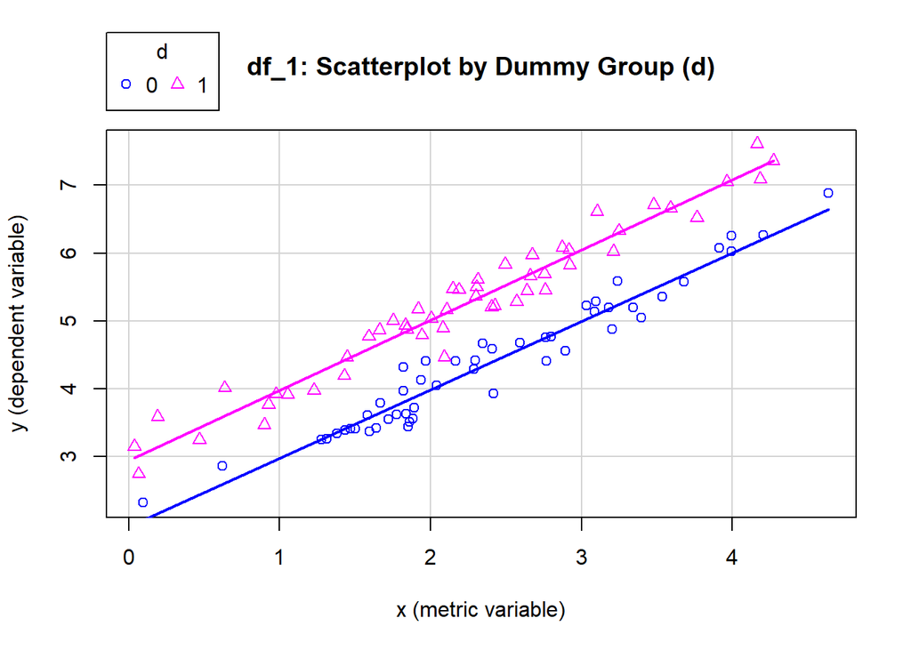

```r
library(car)

load("InteractionWithDummy.RData")     # load df_1 to df_5 into workspace


## Scatterplot and Model Identification for df_1
car::scatterplot(y ~ x | d, data = df_1,
                 smooth=F,
                 xlab  = "x (metric variable)",
                 ylab  = "y (dependent variable)",
                 main  = "df_1: Scatterplot by Dummy Group (d)")
```

The scatterplot for `df_1` shows two distinct groups separated by the dummy variable `d`. Both groups (d = 0 in blue circles and d = 1 in pink triangles) display a clear positive relationship between `x` and `y`. Importantly, the two regression lines appear to run **parallel to each other** — they have approximately the **same slope** but clearly **different intercepts**, with the d = 1 group consistently sitting higher than the d = 0 group across the entire range of `x`.

This pattern is best described by the **different intercept model**:

```r
mod.int <- lm(y ~ d + x, data = df_1)
```

In this model, the dummy variable `d` shifts the regression line **up or down** (intercept effect), while the slope of `x` remains the same for both groups.

**3.2** Plot the data and identify the underlying model structure for `df_2`. [0.2 points]

*Your answer goes here*

### answer 3-2

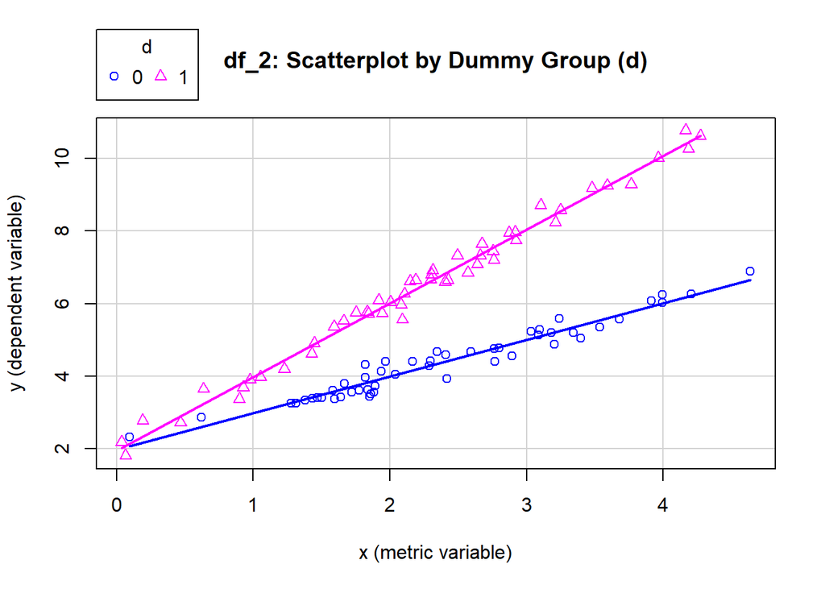

```r
## Scatterplot and Model Identification for df_2
car::scatterplot(y ~ x | d, data = df_2,
                 smooth=F,
                 xlab  = "x (metric variable)",
                 ylab  = "y (dependent variable)",
                 main  = "df_2: Scatterplot by Dummy Group (d)")
```

The scatterplot for `df_2` shows two distinct groups, separated by the dummy variable `d`. Both groups (d = 0 in blue circles and d = 1 in pink triangles) show a clear positive relationship between `x` and `y`. Notably, the two regression lines seem to share the **same intercept** at approximately 2, but they have distinctly **different slopes**, with the d = 1 group exhibiting a steeper slope than the d = 0 group.

This pattern is best described by the **different slope model**:

```r
mod.slope <- lm(y ~ d:x, data = df_2)
```

In this model, the dummy variable `d` splits the regression into **two different slopes**, while the **intercept remains the same** for both groups.

**3.3** Plot the data and identify the underlying model structure for `df_3`. [0.2 points]

*Your answer goes here*

### answer 3-3

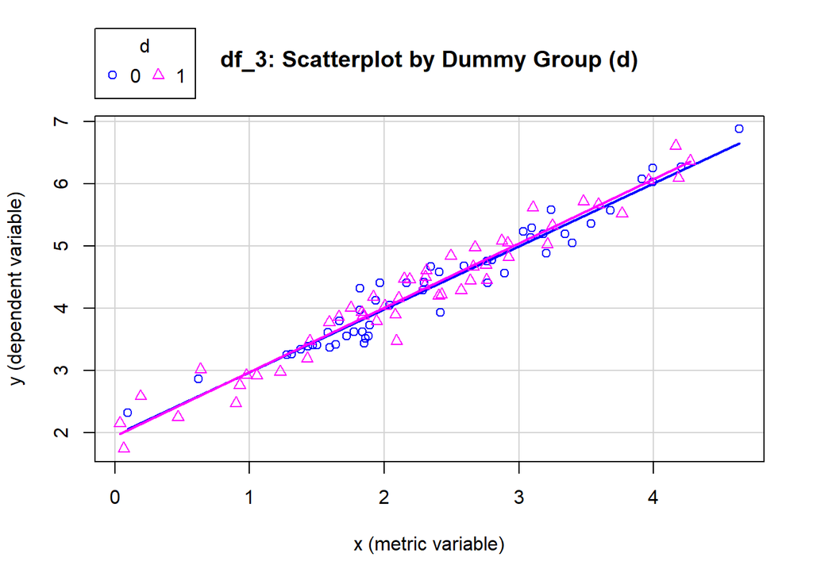

```r
## Scatterplot and Model Identification for df_3
car::scatterplot(y ~ x | d, data = df_3,
                 smooth=F,
                 xlab  = "x (metric variable)",
                 ylab  = "y (dependent variable)",
                 main  = "df_3: Scatterplot by Dummy Group (d)")
```

The scatterplot for `df_3` shows two groups separated by the dummy variable `d`. Both groups (d = 0 in blue circles and d = 1 in pink triangles) display a clear positive relationship between `x` and `y`. The two regression lines appear to share **the same intercept and the same slope**, making them nearly **overlap completely** on the plot. This suggests that the dummy variable `d` has no meaningful effect on `y`.

This pattern is best described by the **plain bivariate model**:

```r
mod.plain <- lm(y ~ x, data = df_3)
```

In this model, only `x` drives the variation in `y`, and the grouping by `d` does not add any explanatory power.

**3.4** Plot the data and identify the underlying model structure for `df_4`. [0.2 points]

*Your answer goes here*

### answer 3-4

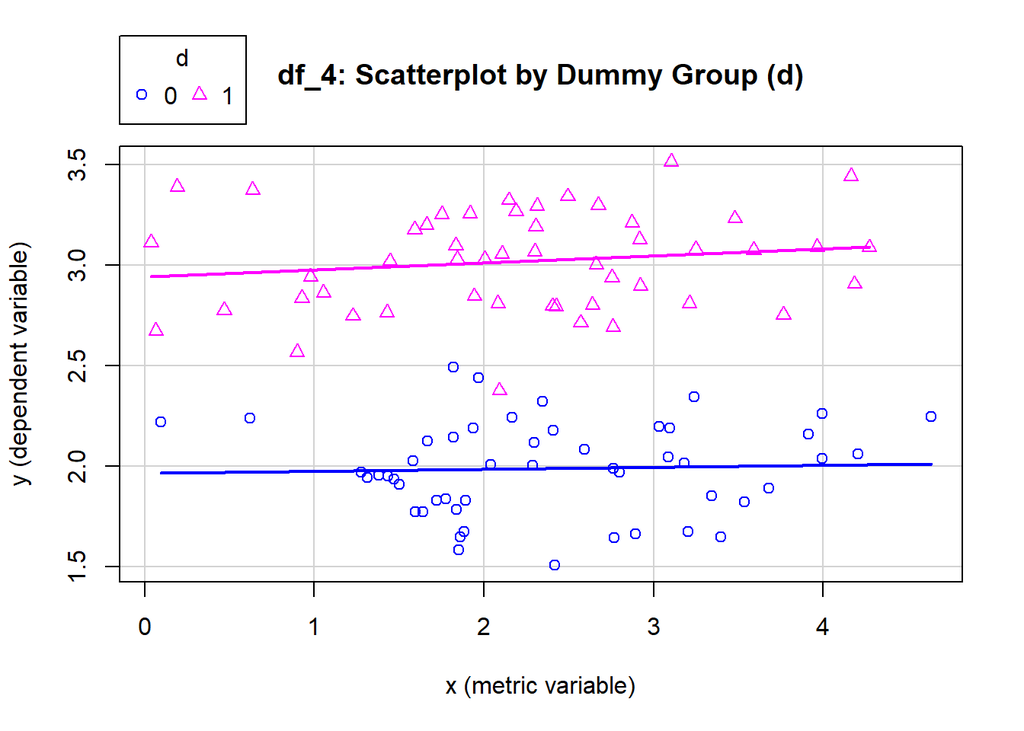

```r
## Scatterplot and Model Identification for df_4
car::scatterplot(y ~ x | d, data = df_4,
                 smooth=F,
                 xlab  = "x (metric variable)",
                 ylab  = "y (dependent variable)",
                 main  = "df_4: Scatterplot by Dummy Group (d)")
```

The scatterplot for `df_4` shows two distinct groups separated by the dummy variable `d`. Both groups (d = 0 in blue circles and d = 1 in pink triangles) display approximately **horizontal regression lines**, indicating that `x` has no meaningful effect on `y`. The d = 0 group stays consistently **lower** while the d = 1 group stays consistently **higher**, suggesting only a difference in group means.

This pattern is best described by the **just different means model**:

```r
mod.means <- lm(y ~ d, data = df_4)
```

In this model, the dummy variable `d` divides the data into two groups, and the regression lines simply represent the **group means of `y`** for each group. The metric variable `x` does not contribute any explanatory power.

**3.5** Plot the data and identify the underlying model structure for `df_5`. [0.2 points]

*Your answer goes here*

### answer 3-5

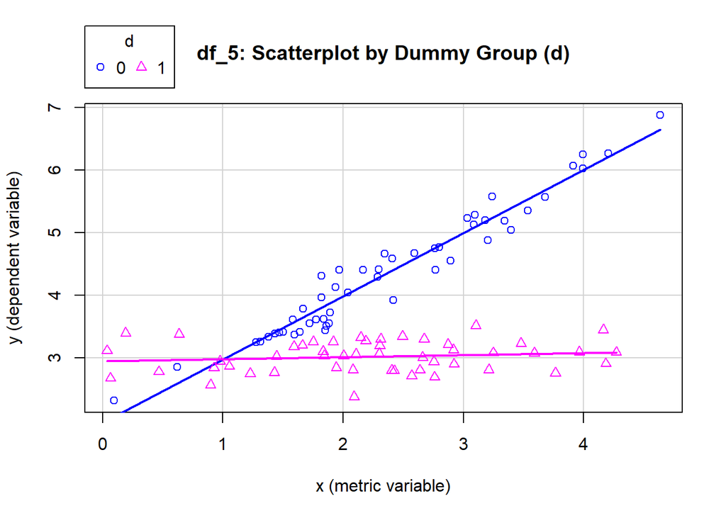

```r
## Scatterplot and Model Identification for df_5
car::scatterplot(y ~ x | d, data = df_5,
                 smooth=F,
                 xlab  = "x (metric variable)",
                 ylab  = "y (dependent variable)",
                 main  = "df_5: Scatterplot by Dummy Group (d)")
```

The scatterplot for `df_5` shows two distinct groups separated by the dummy variable `d`. The d = 0 group (blue circles) displays a **steep positive slope**, while the d = 1 group (pink triangles) shows a nearly **horizontal line** around y = 3. Importantly, the two regression lines have both **different intercepts** — the blue line starts much lower at x = 0 — and **different slopes**, with the blue line rising sharply while the pink line remains almost flat.

This pattern is best described by the **full interaction model**:

```r
mod.full <- lm(y ~ d*x, data = df_5)
```

In this model, the dummy variable `d` affects both the **intercept** and the **slope** simultaneously, allowing each group to have a completely independent regression line. This is the most flexible model among the five competing structures.